# My Coursera Machine Learning Project

Joe Krebs

11/10/2016

## 2. Data Loading

Here we load the training and testing data sets. “#DIV/0!” entries are converted to NA, “user_name”, “new_window”, “classe”, and “problem_id” columns are created as factors and remaining columns are created as numeric or integer.

```r
pml.training <- read.csv(file="https://d396qusza40orc.cloudfront.net/predmachlearn/pml-training.csv",
                         na.strings = "#DIV/0!",
                         colClasses = c("user_name"="factor", "new_window"="factor", "classe"="factor"),
                         as.is = TRUE)
pml.testing <- read.csv(file="https://d396qusza40orc.cloudfront.net/predmachlearn/pml-testing.csv",
                        na.strings = "#DIV/0!",
                        colClasses = c("user_name"="factor", "new_window"="factor", "problem_id"="factor"),
                        as.is = TRUE)
```

## 3. Training Data Partitioning

We partition the input training data set into training (70%) and validation (30%) sets.

```r
set.seed(123)
inTrain <- createDataPartition(y=pml.training$classe,
                               p=0.7,
                               list=FALSE)
training <- pml.training[inTrain,]
validation <- pml.training[-inTrain,]
```

## 4. Data Cleansing and Preparation

To be useful as predictors, feature variables (columns) should have sufficient variance and be reasonably dense and uncorrelated with each other. The training data contains many unuseful columns, which should be removed.

### Column Removal

The data is cleansed by removing the following:

- columns containg serial observation number and observation times
- columns with near zero variance
- columns containing > 50% NA
- columns having > 75% correlation with other columns (keep one, drop others)

```r
# Drop observation number and time
training[, c(1, 3:5)] <- NULL

# Drop columns with insufficient variance
training[, nearZeroVar(training, saveMetrics=FALSE)] <- NULL

# Drop columns with > 50% NA values
cutoff <- 0.5
drop.cols <- NULL
for (clm in 1:ncol(training)) {
    if (length(which(is.na(training[,clm]))) > cutoff * nrow(training)) {
        drop.cols <- union(drop.cols, clm)
    }
}
training[, drop.cols] <- NULL

# Drop columns with > 75% correlation with other columns
cutoff <- 0.75
drop.cols <- NULL
cr <- cor(training[, c(2:54)])
cr[lower.tri(cr, diag=TRUE)] <- NA
for (rw in 1:(nrow(cr) - 1)) {
    for (cl in (rw + 1):ncol(cr)) {
        if (abs(cr[rw, cl]) > cutoff) drop.cols <- union(drop.cols, cl + 1)
    }
}
training[, drop.cols] <- NULL
```

### Post-Cleansing

```r
str(training)
```

```
## 'data.frame':    13737 obs. of  35 variables:
##  $ user_name           : Factor w/ 6 levels "adelmo","carlitos",..: 2 2 2 2 2 2 2 2 2 2 ...
##  $ num_window          : int  11 12 12 12 12 12 12 12 12 12 ...
##  $ roll_belt           : num  1.42 1.48 1.45 1.42 1.42 1.43 1.45 1.45 1.43 1.42 ...
##  $ pitch_belt          : num  8.07 8.05 8.06 8.09 8.13 8.16 8.17 8.18 8.18 8.2 ...
##  $ gyros_belt_x        : num  0 0.02 0.02 0.02 0.02 0.02 0.03 0.03 0.02 0.02 ...
##  $ gyros_belt_y        : num  0 0 0 0 0 0 0 0 0 0 ...
##  $ gyros_belt_z        : num  -0.02 -0.03 -0.02 -0.02 -0.02 -0.02 0 -0.02 -0.02 0 ...
##  $ magnet_belt_y       : int  600 604 603 599 603 602 609 596 602 606 ...
##  $ roll_arm            : num  -128 -128 -128 -128 -128 -128 -128 -128 -128 -128 ...
##  $ pitch_arm           : num  22.5 22.1 22 21.9 21.8 21.7 21.6 21.5 21.5 21.4 ...
##  $ yaw_arm             : num  -161 -161 -161 -161 -161 -161 -161 -161 -161 -161 ...
##  $ total_accel_arm     : int  34 34 34 34 34 34 34 34 34 34 ...
##  $ gyros_arm_x         : num  0.02 0.02 0.02 0 0.02 0.02 0.02 0.02 0.02 0.02 ...
##  $ gyros_arm_z         : num  -0.02 0.02 0 0 0 -0.02 -0.02 0 0 -0.02 ...
```

[output cut: 21 more lines]

## 5. Candidate Model Fits

Since the problem is one of classification (the dependent variable is a factor), we explore model fits for the following candidate models:

- regression tree (“rpart”)
- gradient boosting (“gbm”)
- random forest (“rf”)

### Features

For each, we include all features and preprocess numeric columns by centering and scaling.

### Cross Validation

K-fold cross validation with k=5 folds is used to prevent overfitting.

```r
set.seed(234)
tr <- trainControl(method = "cv", number = 5)
rpart.fit <- train(classe~., data=training, preProcess=c("center","scale"),
                   method="rpart", trControl=tr)
gbm.fit <- train(classe~., data=training, preProcess=c("center","scale"),
                 method="gbm", trControl=tr)
rf.fit <- train(classe~., data=training, preProcess=c("center","scale"),
                method="rf", trControl=tr)
```

### Model Fits

Both gradient boosting and random forest methods produce very high within-training accuracy, but regression tree is significantly less accurate.

```r
print(rpart.fit)
```

```
## CART
##
## 13737 samples
##    37 predictor
##     5 classes: 'A', 'B', 'C', 'D', 'E'
##
## Pre-processing: centered (41), scaled (41)
## Resampling: Cross-Validated (5 fold)
## Summary of sample sizes: 10990, 10989, 10990, 10989, 10990
## Resampling results across tuning parameters:
##
##   cp          Accuracy   Kappa
##   0.02354796  0.6411886  0.5445628
##   0.04306107  0.5061538  0.3426667
##   0.11484081  0.3149204  0.0466093
##
## Accuracy was used to select the optimal model using  the largest value.
## The final value used for the model was cp = 0.02354796.
```

```r
print(gbm.fit)
```

```
## Stochastic Gradient Boosting
##
## 13737 samples
##    37 predictor
##     5 classes: 'A', 'B', 'C', 'D', 'E'
##
## Pre-processing: centered (41), scaled (41)
## Resampling: Cross-Validated (5 fold)
## Summary of sample sizes: 10989, 10990, 10988, 10990, 10991
## Resampling results across tuning parameters:
##
##   interaction.depth  n.trees  Accuracy   Kappa
##   1                   50      0.7304354  0.6577664
##   1                  100      0.7990118  0.7454961
##   1                  150      0.8456015  0.8047124
##   2                   50      0.8666383  0.8311296
##   2                  100      0.9298250  0.9112014
##   2                  150      0.9593064  0.9485212
##   3                   50      0.9185408  0.8968911
##   3                  100      0.9688434  0.9605819
##   3                  150      0.9869691  0.9835174
##
## Tuning parameter 'shrinkage' was held constant at a value of 0.1
##
## Tuning parameter 'n.minobsinnode' was held constant at a value of 10
## Accuracy was used to select the optimal model using  the largest value.
## The final values used for the model were n.trees = 150,
##  interaction.depth = 3, shrinkage = 0.1 and n.minobsinnode = 10.
```

```r
print(rf.fit)
```

```
## Random Forest
##
## 13737 samples
##    37 predictor
##     5 classes: 'A', 'B', 'C', 'D', 'E'
##
## Pre-processing: centered (41), scaled (41)
## Resampling: Cross-Validated (5 fold)
## Summary of sample sizes: 10991, 10989, 10988, 10991, 10989
## Resampling results across tuning parameters:
##
##   mtry  Accuracy   Kappa
##    2    0.9938119  0.9921716
##   21    0.9975249  0.9968694
##   41    0.9959233  0.9948435
##
## Accuracy was used to select the optimal model using  the largest value.
## The final value used for the model was mtry = 21.
```

### Out-of-Sample Accuracy

For gradient boosting and random forest, we test out-of-sample accuracy using the validation hold-out sample. Both methods are highly accurate on the validation sample, but random forest is slightly better, with accuracy of 99.97% (error rate of just 0.03%).

#### Gradient Boosting Confusion Matrix:

```r
gbm.predict <- predict(gbm.fit, newdata=validation)
print(confusionMatrix(data=gbm.predict, reference=validation$classe))
```

```
## Confusion Matrix and Statistics
##
##           Reference
## Prediction    A    B    C    D    E
##          A 1673    3    0    0    1
##          B    0 1129   10    0    0
##          C    0    7 1014   15    0
##          D    1    0    1  949   10
##          E    0    0    1    0 1071
##
## Overall Statistics
##
##                Accuracy : 0.9917
##                  95% CI : (0.989, 0.9938)
##     No Information Rate : 0.2845
##     P-Value [Acc > NIR] : < 2.2e-16
##
##                   Kappa : 0.9895
##  Mcnemar's Test P-Value : NA
##
## Statistics by Class:
##
##                      Class: A Class: B Class: C Class: D Class: E
## Sensitivity            0.9994   0.9912   0.9883   0.9844   0.9898
## Specificity            0.9991   0.9979   0.9955   0.9976   0.9998
## Pos Pred Value         0.9976   0.9912   0.9788   0.9875   0.9991
## Neg Pred Value         0.9998   0.9979   0.9975   0.9970   0.9977
## Prevalence             0.2845   0.1935   0.1743   0.1638   0.1839
## Detection Rate         0.2843   0.1918   0.1723   0.1613   0.1820
## Detection Prevalence   0.2850   0.1935   0.1760   0.1633   0.1822
## Balanced Accuracy      0.9992   0.9946   0.9919   0.9910   0.9948
```

#### Random Forest Confusion Matrix:

```r
rf.predict <- predict(rf.fit, newdata=validation)
print(confusionMatrix(data=rf.predict, reference=validation$classe))
```

```
## Confusion Matrix and Statistics
##
##           Reference
## Prediction    A    B    C    D    E
##          A 1674    0    0    0    0
##          B    0 1139    0    0    0
##          C    0    0 1026    2    0
##          D    0    0    0  962    0
##          E    0    0    0    0 1082
##
## Overall Statistics
##
##                Accuracy : 0.9997
##                  95% CI : (0.9988, 1)
##     No Information Rate : 0.2845
##     P-Value [Acc > NIR] : < 2.2e-16
##
##                   Kappa : 0.9996
##  Mcnemar's Test P-Value : NA
##
## Statistics by Class:
##
##                      Class: A Class: B Class: C Class: D Class: E
## Sensitivity            1.0000   1.0000   1.0000   0.9979   1.0000
## Specificity            1.0000   1.0000   0.9996   1.0000   1.0000
## Pos Pred Value         1.0000   1.0000   0.9981   1.0000   1.0000
## Neg Pred Value         1.0000   1.0000   1.0000   0.9996   1.0000
## Prevalence             0.2845   0.1935   0.1743   0.1638   0.1839
## Detection Rate         0.2845   0.1935   0.1743   0.1635   0.1839
## Detection Prevalence   0.2845   0.1935   0.1747   0.1635   0.1839
## Balanced Accuracy      1.0000   1.0000   0.9998   0.9990   1.0000
```

## 6. Results

### Selected Model - Random Forest

The most accurate model proves to be the random forest, with a near perfect accuracy on the validation sample.

### Random Forest Model Variable Importance

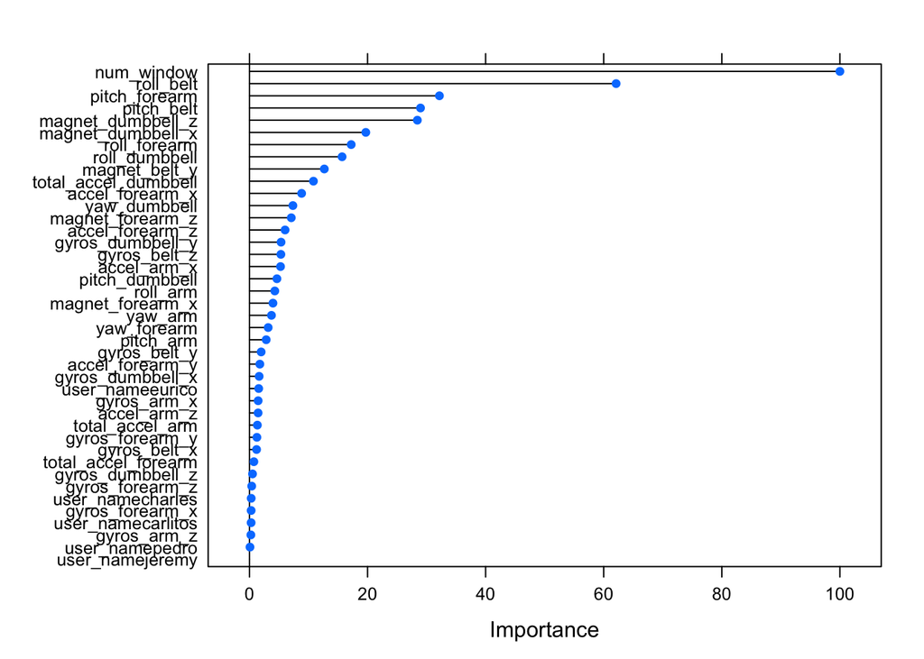

```r
plot(varImp(rf.fit))
```

### Random Forest Final Model Summary

```r
print(summary(rf.fit$finalModel))
```

```
##                 Length Class      Mode
## call                4  -none-     call
## type                1  -none-     character
## predicted       13737  factor     numeric
## err.rate         3000  -none-     numeric
## confusion          30  -none-     numeric
## votes           68685  matrix     numeric
## oob.times       13737  -none-     numeric
## classes             5  -none-     character
## importance         41  -none-     numeric
## importanceSD        0  -none-     NULL
## localImportance     0  -none-     NULL
## proximity           0  -none-     NULL
## ntree               1  -none-     numeric
## mtry                1  -none-     numeric
## forest             14  -none-     list
## y               13737  factor     numeric
## test                0  -none-     NULL
## inbag               0  -none-     NULL
## xNames             41  -none-     character
## problemType         1  -none-     character
## tuneValue           1  data.frame list
## obsLevels           5  -none-     character
```

### Prediction on Test Cases

Using the final random forest model, prediction on the “pml-testing” data is as follows:

```r
rf.predict.test <- predict(rf.fit, newdata=pml.testing)
print(rf.predict.test)
```

```
##  [1] B A B A A E D B A A B C B A E E A B B B
## Levels: A B C D E
```